# Renewvia - Survey Impact Analysis

# Overview

## Descriptive

- Generating summary statistics
- Plotting graphs/charts

## **Inferential**

- For the paired data set, we will use the following
  - Paired t-Test for ratio
  - Wilcoxon Signed Rank Test (Sign Test if asymmetric) for ordinal variables
  - McNemar’s Test for binary responses
- Our independent variables will be the following: PV Size (kWh), No. of Customers, CAPEX (USD) and Consumption (Community & Customer).
- For each dependent variables, we will run a uni-variate regression tests with each of independent variable. When applicable, we will have a Linear regression t-Test or Logistic regression Wald test

# Libraries

```r
# Importing libraries
options(warn=-1)
library(ggplot2)
library(dplyr)
library(lessR)
library(tidyr)
library(ggpubr)
library(exact2x2)
library(stringr)
library(epiDisplay)
library(tibble)
library(ggExtra)
library(vtree)
library(CGPfunctions)
library(psych)
library(nonpar)
library(scales)
library(tidyverse)
library(ggrepel)
library(data.table)
library(forcats)
library(glue)
library(aod)
```

# Input Data

## Community

```r
## Locading the project& consumption data
consumption <- read.csv("customer_consumption.csv")
customer_info <- read.csv("customers_info.csv")

temp <- merge(consumption, customer_info,
              by.x = 'Account.Number',
              by.y = 'customerAccountNumber')
temp_group <- temp %>%
                    group_by(projectName) %>%
                    summarise(consumption = sum(Energy.Consumption, na.rm=TRUE))
projects <- read.csv("project_data.csv")
projects <- merge(projects, temp_group, by.x="project_name", by.y="projectName")
```

## Surveys - Clean

```r
## Locading the cleaned data sets
# Intial Survey
initial <- read.csv("data_cleaning/datasets_clean/initial_clean.csv",
                          na.strings=c("","NA"))
initial_clean <- merge(initial, customer_info,
                     by.x = 'renewvia_id',
                     by.y = 'customerAccountNumber') %>%
                    filter(tariff == "Residential")
# Pre-connection
initial_pre <- initial_clean %>%
                    filter(status == "pre_connection")

# Post-connection
initial_post <- initial_clean %>%
                    filter(status == "post_connection")

# Household Post-Survey
post <- read.csv("data_cleaning/datasets_clean/post_clean.csv",
                          na.strings=c("","NA"))
post_clean <- merge(post, temp,
                       by.x = 'renewvia_id',
                       by.y = 'Account.Number')%>%
                    filter(tariff == "Residential")

## Pairing pre and post responses
paired_clean <- merge(initial_pre, post_clean,
                      suffix = c("_pre", "_post"),
                      by= 'renewvia_id')

# Commercial & Insitution Post-Survey
ci <- read.csv("data_cleaning/datasets_clean/ci_post_clean.csv",
                          na.strings=c("","NA"))
ci_clean <- merge(ci, temp,
                       by.x = 'renewvia_id',
                       by.y = 'Account.Number')
# head(ci_clean)
```

## Surveys - Encoded

```r
## Locading the encoded data sets
# Intial Survey
initial_enc <- read.csv("data_cleaning/datasets_encoded/initial_encoded.csv",
                          na.strings=c("","NA"))
initial_enc <- merge(initial_enc, customer_info,
                     by.x = 'renewvia_id',
                     by.y = 'customerAccountNumber') %>%
                    filter(tariff == "Residential")
# Pre-connection
initial_pre_enc <- initial_enc %>%
                    filter(status == 1)
# Pre-connection
initial_post_enc <- initial_enc %>%
                    filter(status == 2)

# Household Post-Survey
post <- read.csv("data_cleaning/datasets_encoded/post_encoded.csv",
                          na.strings=c("","NA"))
post_enc <- merge(post, temp,
                       by.x = 'renewvia_id',
                       by.y = 'Account.Number')  %>%
                    filter(tariff == "Residential")

# Commercial & Insitution Post-Survey
ci <- read.csv("data_cleaning/datasets_encoded/ci_post_encoded.csv",
                          na.strings=c("","NA"))
ci_enc <- merge(ci, temp,
                 by.x = 'renewvia_id',
                 by.y = 'Account.Number')

paired_enc <- merge(initial_pre_enc, post_enc,
                      suffix = c("_pre", "_post"),
                      by= 'renewvia_id')
```

# Utility Functions

## Descriptive

```r
get_stats <- function(data, ct, var_name,data_source,
                      remove_outliers = FALSE,
                      exclude_zeros = FALSE) {
  if (grepl("_pre", var_name, fixed = TRUE)){
    country_data <- data %>% filter(country_pre == ct)
  } else if (grepl("_post", var_name, fixed = TRUE)){
    country_data <- data %>% filter(country_post == ct)
  } else {country_data <- data %>% filter(country == ct)}

  if (remove_outliers == TRUE) {
    print("Excluding outliers")
    quartiles <- quantile(country_data[, var_name],
                        probs=c(.25, .75), na.rm = TRUE)

    IQR <- IQR(country_data[, var_name], na.rm = TRUE)

    Lower <- quartiles[1] - 1.5*IQR
    Upper <- quartiles[2] + 1.5*IQR

    country_data <- subset(country_data,
                              country_data[, var_name] > Lower &
                              country_data[, var_name] < Upper)
  }

  var <- country_data[, var_name]

  if (exclude_zeros == TRUE) {
    print("Removing Zeros")
    var <- var[var != 0]
  }

  stats <- t(describe(var, IQR=TRUE, quant=c(.1,.25,.5,.75,.90),))
  print(t.test(var, conf.level = 0.95))
  print(stats)
}
```

## Data Visualization

```r
remove_y <- theme(
  # axis.text.x = element_blank(),
  # axis.ticks.x = element_blank(),
  # axis.title.x = element_blank(),
  axis.text.y = element_blank(),
  axis.ticks.y = element_blank(),
  axis.title.y = element_blank()
)
```

### Plot graphs with ggplot

```r
# For pie and bar charts
plot_func <- function(df, var_name, var_type,
                      plot_title, plot_type, char_remove=NULL,
                      remove_outliers = FALSE) {
  if(is.null(char_remove) == FALSE) {
    df <- df %>% filter(.data[[var_name]] != char_remove)
  }

  if(remove_outliers == TRUE) {
      print("Removing outliers")
      quartiles <- quantile(df[, var_name],
                        probs=c(.25, .75), na.rm = TRUE)

      IQR <- IQR(df[, var_name], na.rm = TRUE)

      Lower <- quartiles[1] - 1.5*IQR
      Upper <- quartiles[2] + 1.5*IQR

      df <- subset(df,
                     df[, var_name] > Lower &
                     df[, var_name]< Upper)
    }
  if(var_type == "non_cont") {
      var <- df[, var_name]
      var <- var[var != ""]

      data <- as.data.frame(t(table(var)))[,2:3]
      setnames(data,
               old = c('var','Freq'),
               new = c('labels','counts'))



      if (plot_type == 'pie') {
          data_tab <- data %>% mutate(csum = rev(cumsum(rev(counts))),
                                 pos = counts/2 + lead(csum, 1),
                                 pos = if_else(is.na(pos), counts/2, pos),
                                 percentage = counts/sum(counts))
          data_tab$labels <- as.factor(data_tab$labels)
          plot <- data_tab %>% ggplot(aes(x = "", y = counts, fill = labels)) +
                              geom_col(width = 1, color = 1) +
                              geom_label_repel(
                                aes(y = pos,
                                    label = glue("{counts} ({percent(percentage)})"),
                                     fill = labels),
                                    show.legend = FALSE) +
                              labs(fill = var_name, title=plot_title) +
                              coord_polar(theta = "y") +
                              theme_void() +
                              theme(legend.text=element_text(size=6))
      } else if (plot_type == "bar") {
          plot <- data %>% ggplot(aes(y=counts,
                                      x=reorder(labels, counts),
                                      fill=labels)) +
                            geom_col(width = 0.7) +
                            geom_text(aes(label=counts), vjust=-0.3, size=3)+
                            labs(fill = var_name, title=plot_title) +
                            coord_flip() +
                            theme(legend.text=element_text(size=6))
      } else if (plot_type == "bar_discrete") {
          plot <- data %>% ggplot(aes(y=counts, x=labels)) +
                            geom_col(width = 0.7) +
                            labs(title=plot_title, x = var_name)
      }
  }else if(var_type == "cont") {
      if(plot_type == "hist") {
        plot <- ggplot(df, aes(x=.data[[var_name]])) +
                      geom_histogram(stat = "count",
                                     fill = 'yellow',
                                     alpha = 0.7,
                                     col = 'black', bins=10) +
                      geom_vline(xintercept = mean(df[,var_name], na.rm=TRUE),
                                 col="lightblue", lty=1, lwd = 1) +
                      geom_vline(xintercept = median(df[,var_name], na.rm=TRUE),
                               col="purple", lty=2, lwd = 1) +
                      theme_bw() +
                      labs(title=plot_title)
      }else if(plot_type == "boxplot") {
        plot <- ggplot(df, aes(x=.data[[var_name]])) +
                geom_boxplot(outlier.colour="red",
                              outlier.size=4)+
                labs(title=plot_title) +
                theme_void()
    }
  }
  return(plot)
}
```

### Pre-Post Comparison

```r
compare_pre_post <- function(var_name, var_type, subplot_type, title,
                             exclude_outliers = FALSE,
                             char_remove=NULL, shared_legend=TRUE) {

  pre_plot <- plot_func(initial_pre, var_name, var_type,
                         "Initial", subplot_type,
                        char_remove, remove_outliers=exclude_outliers)
  post_plot <- plot_func(post_clean, var_name, var_type,
                          "Post", subplot_type,
                         char_remove, remove_outliers=exclude_outliers)
  if (subplot_type == "bar") {
        plot <- ggarrange(post_plot + remove_y, pre_plot + remove_y,
                          ncol = 2,  nrow = 1,
                          common.legend = shared_legend,legend="bottom")
  } else {
        plot <- ggarrange(post_plot, pre_plot,
                        ncol = 2, nrow = 1,
                        common.legend = shared_legend,
                        legend="right")
  }

  return(annotate_figure(plot,
                         top = text_grob(title, color = "black",
                                         face = "bold", size = 12)))

}
```

### Comparison in same data

```r
compare_in_df <- function(data, var1, var2,
                            var1_title, var2_title,
                            subplot_type, plot_title,
                          var_type,
                          char_remove=NULL){
  var1_plot <- plot_func(data, var1, var_type,
                          var1_title, subplot_type, char_remove)
  var2_plot <- plot_func(data, var2, var_type,
                          var2_title, subplot_type, char_remove)
  if (subplot_type == "bar") {
        plot <- ggarrange(var2_plot + remove_y, var1_plot + remove_y,
                          ncol = 2,  nrow = 1,
                          common.legend = TRUE,legend="bottom")
  } else {
        plot <- ggarrange(var2_plot, var1_plot,
                        ncol = 2, nrow = 1,
                        common.legend = TRUE,
                        legend="right")
  }

  return(annotate_figure(plot, top = text_grob(plot_title,
                 color = "black", face = "bold", size = 12)))
}
```

## Hypothesis Testing

```r
# Running the paired t-test
paired_testing <- function(data, var_name, test_type,
                           plot_diff=FALSE, plot_title=NULL, remove_outliers=FALSE) {
  pre_name <- paste(var_name, "pre", sep="_")
  post_name <- paste(var_name, "post", sep="_")

  sprintf("Removing outliers for both %s and %s", pre_name, post_name)
  vars <- c(pre_name, post_name)
  if(remove_outliers==TRUE) {
    for(var in vars){
      quartiles <- quantile(data[, var],
                        probs=c(.25, .75), na.rm = TRUE)

      IQR <- IQR(data[, var], na.rm = TRUE)

      Lower <- quartiles[1] - 1.5*IQR
      Upper <- quartiles[2] + 1.5*IQR

      data <- subset(data,
                     data[, var] > Lower &
                     data[, var] < Upper)
    }
  }
  var_pre <- data[, pre_name]
  var_post <- data[, post_name]
  diff <- var_post - var_pre
  # Running the test
  if(test_type == "wilcoxon"){
    #Wilcoxon Signed-Rank Test
    test <- wilcox.test(var_pre, var_post, paired=TRUE)
  }else if(test_type == "sign") {
    #Sign Test
    test <- signtest(diff, m=0, conf.level=0.95, exact=FALSE)
  } else if (test_type == "ttest") {
    #Paired t-Test
    test <- t.test(var_pre, var_post,
         paired = TRUE, alternative = "two.sided")
  } else if(test_type == "mcnemar") {
    cross_tab <- table(var_pre, var_post)
    print(cross_tab)
    test <- mcnemar.test(cross_tab)
  }

  # Visualize distribution of score differences
  if(plot_diff == TRUE) {
      hist(diff, main=plot_title)
  }
  return(test)
}
```

## Regression Testing

### Plotting Scatter-plots

```r
plot_reg <- function(data, feature, dependent,
                     remove_outliers=TRUE, reg_type,
                     vals_remove=NULL) {

  if(is.null(vals_remove) == FALSE) {
    data <- data[!grepl(vals_remove,data$dependent),]
  }
  if(remove_outliers == TRUE) {
    vars <- c(feature, dependent)
    for(var in vars){
      quartiles <- quantile(data[, var],
                        probs=c(.25, .75), na.rm = TRUE)

      IQR <- IQR(data[, var], na.rm = TRUE)

      Lower <- quartiles[1] - 1.5*IQR
      Upper <- quartiles[2] + 1.5*IQR

      data <- subset(data,
                     data[, var] > Lower &
                     data[, var] < Upper)
    }

  }
  if(reg_type == "linear") {
    plot <- ggplot(data,
                aes(x=.data[[feature]], y=.data[[dependent]])) +
                geom_point(color='blue') +
                  geom_smooth(color='red', method = "lm", se = FALSE) +
                theme_classic()
  } else if(reg_type == "logistic") {
     plot <- ggplot(data,
                    aes(x=.data[[feature]], y=.data[[dependent]])) +
              geom_point(color='blue', alpha=.5) +
              stat_smooth(method="glm", color="red", se=FALSE,
                        method.args = list(family=binomial)) +
                theme_classic()
  }

  return(plot)
}
```

### Community Ind. Variables

```r
ind_vars <- c("pv_size_kwh", "customer_count", "capex_usd", "consumption")

community_reg <- function(df, col_name, dep, title,
                          var_type, calc_diff=FALSE, to_remove=NULL) {
  if (calc_diff == TRUE) {
      pre_name <- paste(col_name, "pre", sep="_")
      post_name <- paste(col_name, "post", sep="_")
      df$col_reg <- df[, post_name] - df[, pre_name]
      names(df)[names(df) == "community_post"] <- "community"
  } else {
      df$col_reg <- df[, col_name]
  }

  if(var_type == "categorical") {
    data <- rownames_to_column(as.data.frame.matrix(
                                  prop.table(table(
                                      df[, "community"],
                                      df[, "col_reg"]),
                                     margin = 1)
                                              )
                                  , var = "community")
  } else if(var_type == "ratio") {
    data <- as.data.frame(rowsum(df[, "col_reg"],
                                 df[, "community"], na.rm = TRUE))
    data$community <- rownames(data)


  }
  community_data <- merge(x=projects, y=data, by="community")
  lst <- list()

   for(ind in ind_vars) {
        print(ind)
          p <- plot_reg(data=community_data, feature=ind,
                        dependent=dep, reg_type="linear", vals_remove=to_remove)
          lst <- append(lst, list(p))
          lm <- lm(community_data[,dep] ~ community_data[,ind])
          details <- summary(lm)
          result <- as.data.frame(details$coefficients, row.names = c("Intercept", ind))
          print(result)
          print(confint(lm, level=0.95))
      }
  plot <- ggarrange(plotlist = lst,
                    ncol = 2, nrow = 2,
                    common.legend = TRUE,
                    legend="right")
  annotate_figure(plot, top = text_grob(title,
                 color = "black", face = "bold", size = 12))
}
```

### Customer Consumption

```r
consumption_reg <- function(df, dep, title, reg_type,
                            calc_diff=FALSE, exclude_outliers = FALSE,
                            to_remove=NULL) {

  if(reg_type == "linear") {
    if (calc_diff == TRUE) {
      pre_name <- paste(dep, "pre", sep="_")
      post_name <- paste(dep, "post", sep="_")
      df$col_reg <- df[, post_name] - df[, pre_name]
    } else {
      df$col_reg <- df[, dep]
    }

    model <- lm(df$col_reg ~ df$Energy.Consumption)
    p <- plot_reg(data=df, feature="Energy.Consumption",
                  dependent="col_reg", reg_type="linear",
                  remove_outliers=exclude_outliers,
                  vals_remove=to_remove)

  } else if(reg_type == "logistic") {
    model <- glm(df[,dep] ~ df$Energy.Consumption,
               family=binomial)
    p <- plot_reg(data=df, feature="Energy.Consumption",
                  dependent=dep, reg_type="logistic",
                  remove_outliers=exclude_outliers,
                  vals_remove=to_remove)
    test <- wald.test(Sigma = vcov(model),
                      b = coef(model), Terms = 1)
    print(test)
  }

  print(summary(model))
  print(confint(model, level=0.95))

  return(p)

}
```

# 1- Gender Equality

## A) Descriptive

### Demographics

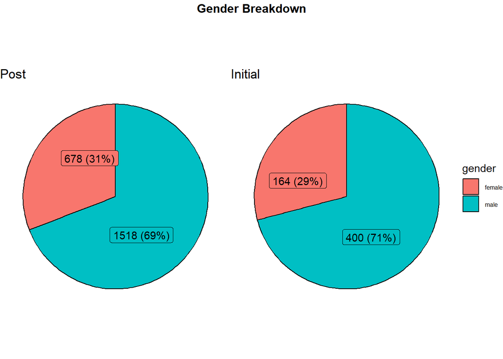

```r
# What was the gender breakdown of survey respondents, pre and post?
compare_pre_post(var_name="gender", var_type="non_cont",
        subplot_type="pie", title="Gender Breakdown")
```

### School Enrollment

```r
# What was school enrollment by gender pre-connection?
girls <- sum(initial_pre$girls_headcount,na.rm = TRUE)
girls_in_school <- sum(initial_pre$girls_schooling,na.rm = TRUE)
enrollment_rate <- percent(girls_in_school/girls, accuracy = 0.01)

vals <- c(girls, girls_in_school, enrollment_rate)

# creating matrix
tab <- as.data.frame(t(as.matrix(vals)))
setnames(tab, old = c('V1','V2', 'V3'),
          new = c("Girls", "Girls.In.School", "Enrollment.Rate"))
tab
```

| Girls | Girls.In.School | Enrollment.Rate |
| --- | --- | --- |
| 1080 | 719 | 66.57% |

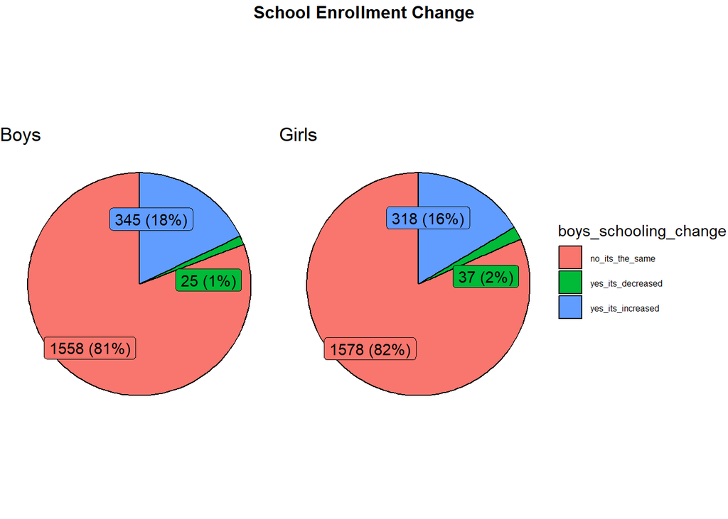

```r
# Was there a change in enrollment by gender afterwards?
compare_in_df(data=post_clean, var_type="non_cont",
               var1="girls_schooling_change",
               var2="boys_schooling_change",
               var1_title="Girls", var2_title="Boys",
               subplot_type="pie", plot_title="School Enrollment Change")
```

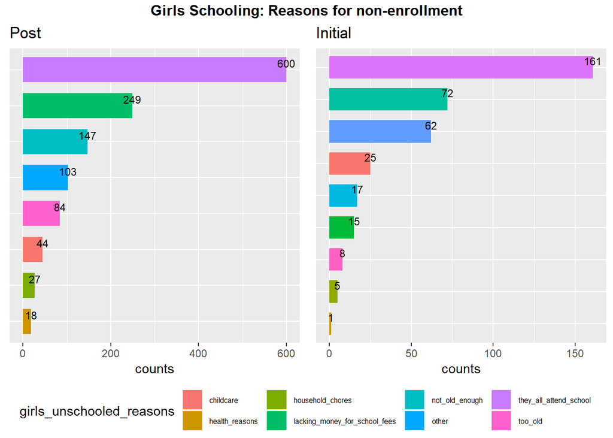

```r
# Dirving factor for non-enrollment in school for boys and girls
# For Girls
compare_pre_post(var_name="girls_unschooled_reasons", var_type="non_cont",
        subplot_type="bar", title="Girls Schooling: Reasons for non-enrollment",
        char_remove=c("they_all_attend_school", ""))
```

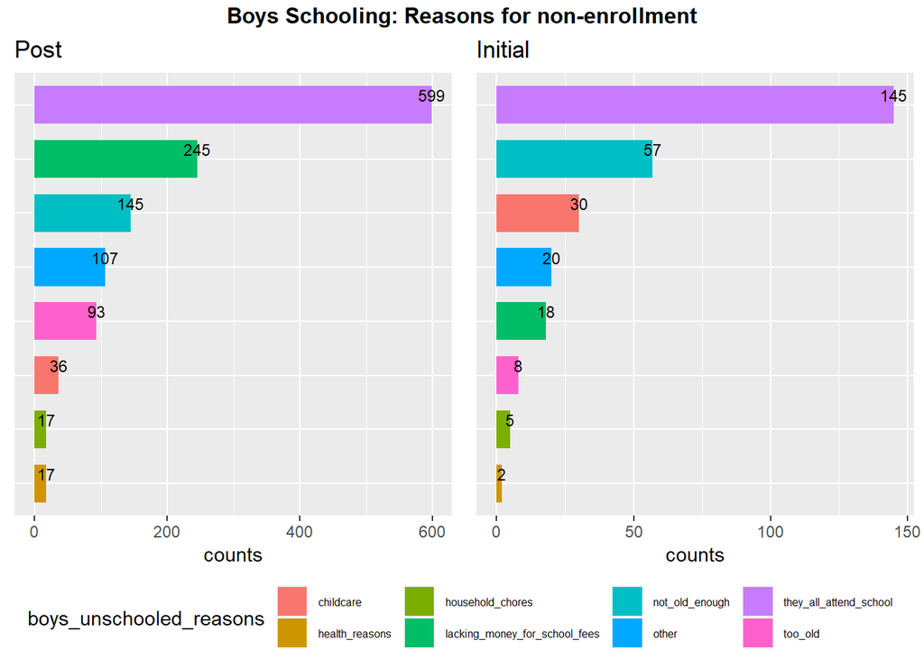

```r
# For Boys
compare_pre_post(var_name="boys_unschooled_reasons",  var_type="non_cont",
        subplot_type="bar", title="Boys Schooling: Reasons for non-enrollment",
        char_remove=c("they_all_attend_school", ""))
```

### Household Chores

[figure not shown]

```r
# What is the average age of the person in charge of water collection?
compare_pre_post(var_name="avg_person_age_water_collection", var_type="non_cont",
        subplot_type="bar", title="Age of Person Responsible for Cooking Fuel Collection")
```

### Female Businesses Ownership

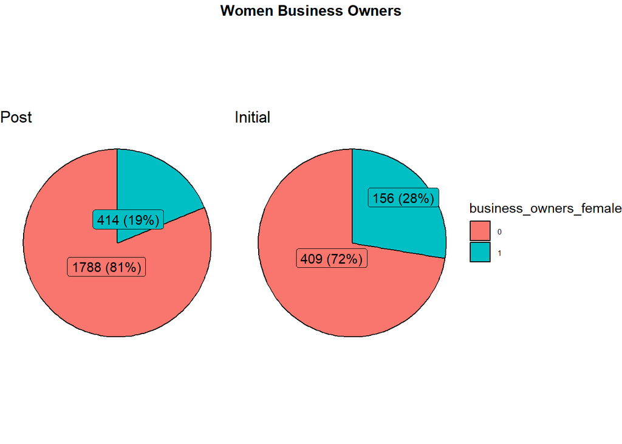

```r
# How many new women-led businesses were created?
compare_pre_post(var_name="business_owners_female", var_type="non_cont",
        subplot_type="pie", title="Women Business Owners")
```

### TODO

```r
# In respondent's own words, how were women affected from the mini-grid?

## Requires additional cleaning/annotations
# Who is mainly responsible for cooking fuel collection on a daily basis? Select all that apply
```

## B) Inferential

### School Enrollment Change

**Data Source**: Household Post-Survey

**Value (Encoding if applied)**: “Yes, it’s decreased” = -1; “No, it’s the same” = 0; “Yes, it’s increased” = 1

#### Linear Regression - Increase

```
## [1] "pv_size_kwh"
##                   Estimate   Std. Error   t value     Pr(>|t|)
## Intercept   0.195216548860 0.0448497797 4.3526758 0.0003836071
## pv_size_kwh 0.000006989608 0.0003603151 0.0193986 0.9847365435
##                               2.5 %       97.5 %
## (Intercept)            0.1009906582 0.2894424396
## community_data[, ind] -0.0007500043 0.0007639835
## [1] "customer_count"
##                      Estimate    Std. Error    t value     Pr(>|t|)
## Intercept       0.20439054295 0.04765600092  4.2888732 0.0004418653
## customer_count -0.00002560674 0.00007239959 -0.3536862 0.7276828829
##                               2.5 %       97.5 %
## (Intercept)            0.1042690003 0.3045120856
## community_data[, ind] -0.0001777126 0.0001264992
## [1] "capex_usd"
##                   Estimate     Std. Error   t value   Pr(>|t|)
## Intercept 0.17700422808163 0.071570852340 2.4731329 0.02358716
## capex_usd 0.00000007249096 0.000000229876 0.3153481 0.75612411
##                                  2.5 %          97.5 %
## (Intercept)            0.0266394469623 0.3273690092010
## community_data[, ind] -0.0000004104606 0.0000005554425
## [1] "consumption"
##                     Estimate      Std. Error    t value     Pr(>|t|)
## Intercept    0.2174390868808 0.0481360510685  4.5171775 0.0002667038
## consumption -0.0000004547138 0.0000005560928 -0.8176941 0.4242241231
##                                 2.5 %          97.5 %
## (Intercept)            0.116308996261 0.3185691775008
## community_data[, ind] -0.000001623021 0.0000007135939
```

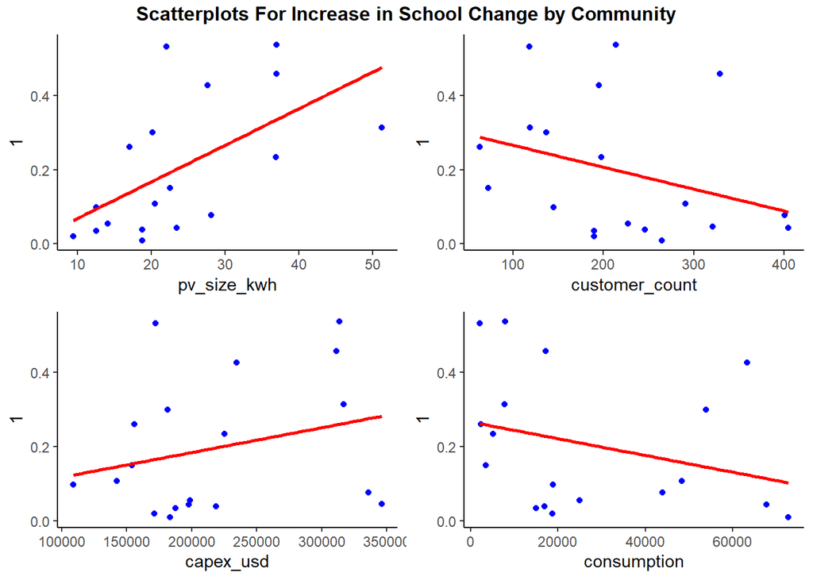

```r
# Check for increase
community_reg(df=post_enc,
              col_name="girls_schooling_change", dep="1", var_type="categorical",
              title="Scatterplots For Increase in School Change by Community")
```

#### Linear Regression - Decrease

```
## [1] "pv_size_kwh"
##                   Estimate    Std. Error    t value    Pr(>|t|)
## Intercept    0.02276379783 0.00737159340  3.0880431 0.006343015
## pv_size_kwh -0.00002469026 0.00005922206 -0.4169098 0.681674203
##                               2.5 %        97.5 %
## (Intercept)            0.0072766548 0.03825094088
## community_data[, ind] -0.0001491112 0.00009973067
## [1] "customer_count"
##                       Estimate    Std. Error    t value    Pr(>|t|)
## Intercept       0.022683851838 0.00787917965  2.8789611 0.009988779
## customer_count -0.000003491188 0.00001197015 -0.2916579 0.773882795
##                                2.5 %        97.5 %
## (Intercept)            0.00613030965 0.03923739402
## community_data[, ind] -0.00002863954 0.00002165716
## [1] "capex_usd"
##                    Estimate       Std. Error    t value   Pr(>|t|)
## Intercept  0.02788515207895 0.01170996474071  2.3813182 0.02849759
## capex_usd -0.00000002498687 0.00000003761084 -0.6643527 0.51488582
##                                  2.5 %           97.5 %
## (Intercept)            0.0032834290647 0.05248687509316
## community_data[, ind] -0.0000001040043 0.00000005403058
## [1] "consumption"
##                      Estimate       Std. Error    t value    Pr(>|t|)
## Intercept    0.02389197001826 0.00803122137196  2.9748862 0.008116443
## consumption -0.00000005011952 0.00000009278087 -0.5401924 0.595685505
##                                  2.5 %          97.5 %
## (Intercept)            0.0070190000278 0.0407649400087
## community_data[, ind] -0.0000002450449 0.0000001448058
```

[figure not shown]

```r
# Check for decrease
community_reg(df=post_enc,
              col_name="girls_schooling_change", dep="-1", var_type="categorical",
              title="Scatterplots For Increase in School Change by Community")
```

### Water Collection Time

**Data Source**: Paired Household Surveys (Pre & Post)

**Value (Encoding if applied)**: “less than 1 hour” = 1; “1-2 hours” = 2; “2-3 hours” = 3; “3-4 hours” = 4; “greater than 4 hours” = 5

#### Pre-Post Comparison

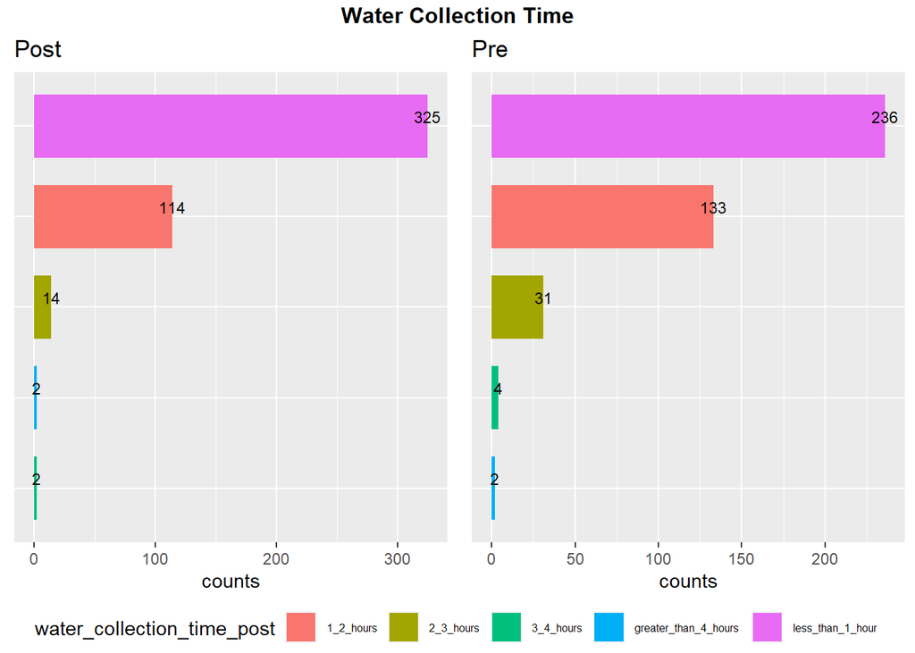

```r
compare_in_df(data=paired_clean, var_type="non_cont",
               var1="water_collection_time_pre",
               var2="water_collection_time_post",
               var1_title="Pre", var2_title="Post",
               subplot_type="bar", plot_title="Water Collection Time")
```

#### Sign-Test

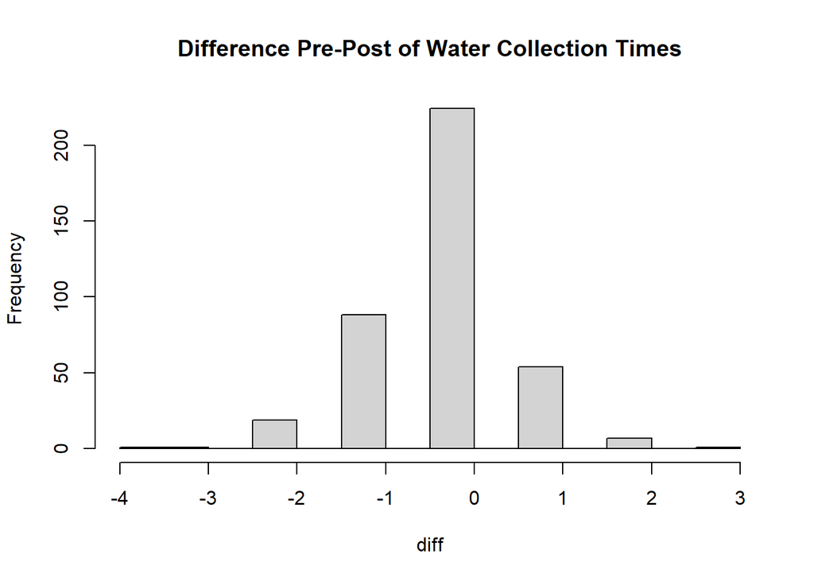

```
##
##  Large Sample Approximation for the Sign Test
##
##  H0: The population median is =  0
##  HA: The population median is not equal to  0
##
##  B = 109
##
##  Significance Level = 0.05
##  The p-value is  0.000435291192669986
##  There is enough evidence to conclude that the population median is different than 0 at a significance level of  0.05
##
##  The  95 % confidence interval is [ -1 ,  -1 ].
##
```

```r
# How long does the water collection process take on a daily basis?
paired_testing(paired_enc, var_name="water_collection_time",
               test_type = "sign", plot_diff=TRUE,
               plot_title="Difference Pre-Post of Water Collection Times")
```

### Cooking Fuel Collection Time

**Data Source**: Paired Household Surveys (Pre & Post)

#### Pre-Post Comparison

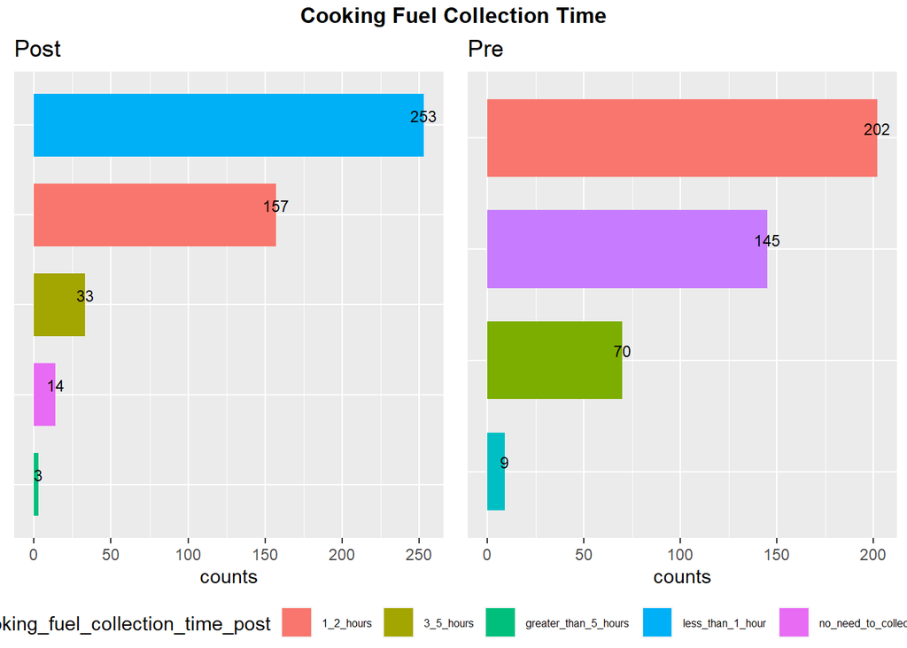

```r
compare_in_df(data=paired_clean, var_type="non_cont",
               var1="cooking_fuel_collection_time_pre",
               var2="cooking_fuel_collection_time_post",
               var1_title="Pre", var2_title="Post",
               subplot_type="bar", plot_title="Cooking Fuel Collection Time")
```

#### Wilcoxon Signed-Rank Test

[figure not shown]

```
##
##  Wilcoxon signed rank test with continuity correction
##
## data:  var_pre and var_post
## V = 27213, p-value = 0.0000000000005313
## alternative hypothesis: true location shift is not equal to 0
```

```r
# How long does the cooking fuel collection process take on a daily basis?
paired_testing(paired_enc, var_name="cooking_fuel_collection_time",
               test_type = "wilcoxon", plot_diff=TRUE,
               plot_title="Difference Pre-Post of Water Collection Times")
```

### Women-led Business Ownership

**Data Source**: Paired Household Surveys (Pre & Post)

**Value (Encoding if applied)**: Everything else = 0; “adult_female” = 1

```r
# Are any household members business owners? Isolate for those with 'adult_'female
paired_testing(paired_enc, var_name="business_owners_female",
               test_type = "mcnemar", plot_diff=FALSE)
```

```
##        var_post
## var_pre   0   1
##       0 265  74
##       1  93  37
```

```
##
##  McNemar's Chi-squared test with continuity correction
##
## data:  cross_tab
## McNemar's chi-squared = 1.9401, df = 1, p-value = 0.1637
```

### New Female workers

**Data Source**: Commercial & Institution Post Survey

**Value (Encoding if applied)**: Any value

```r
# If you answered yes to adding new workers, how many new employees are female?
# Check for increase
community_reg(df=ci_enc,
              col_name="workforce_change_female", dep="V1",
              title="New Female Workers Change by Community",
              var_type="ratio")
```

[output not shown]

[figure not shown]

# 2- Productivity

## A) Descriptive

### Power Source

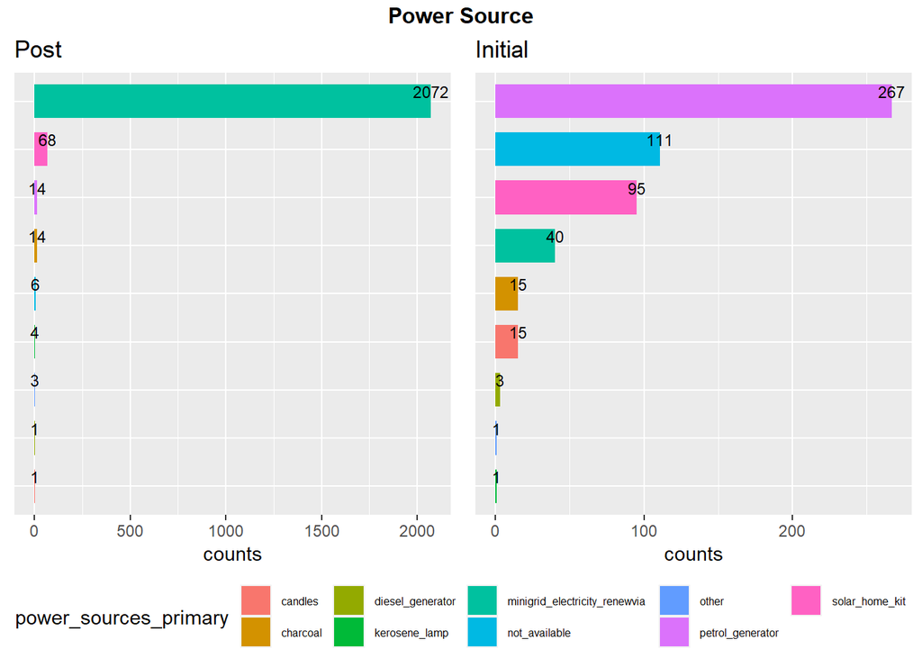

```r
# What is your primary power source?
compare_pre_post(var_name="power_sources_primary", var_type="non_cont",
                 subplot_type="bar", title="Power Source",
                 char_remove=NULL)
```

### Light Hours

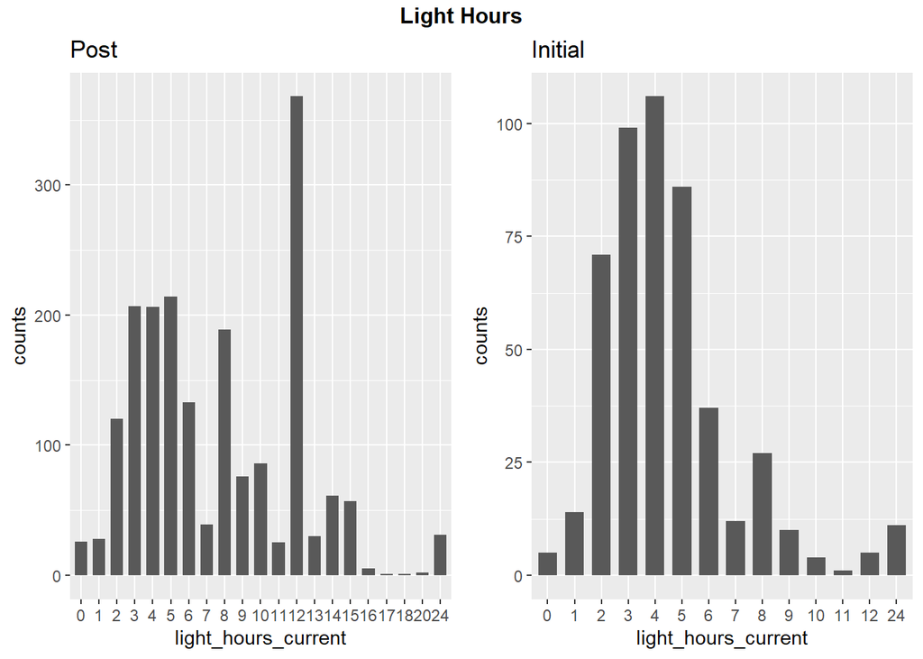

```r
compare_pre_post(var_name="light_hours_current", var_type="non_cont",
                 subplot_type="bar_discrete", title="Light Hours",
                 char_remove=c(46))
```

### No. of Appliances

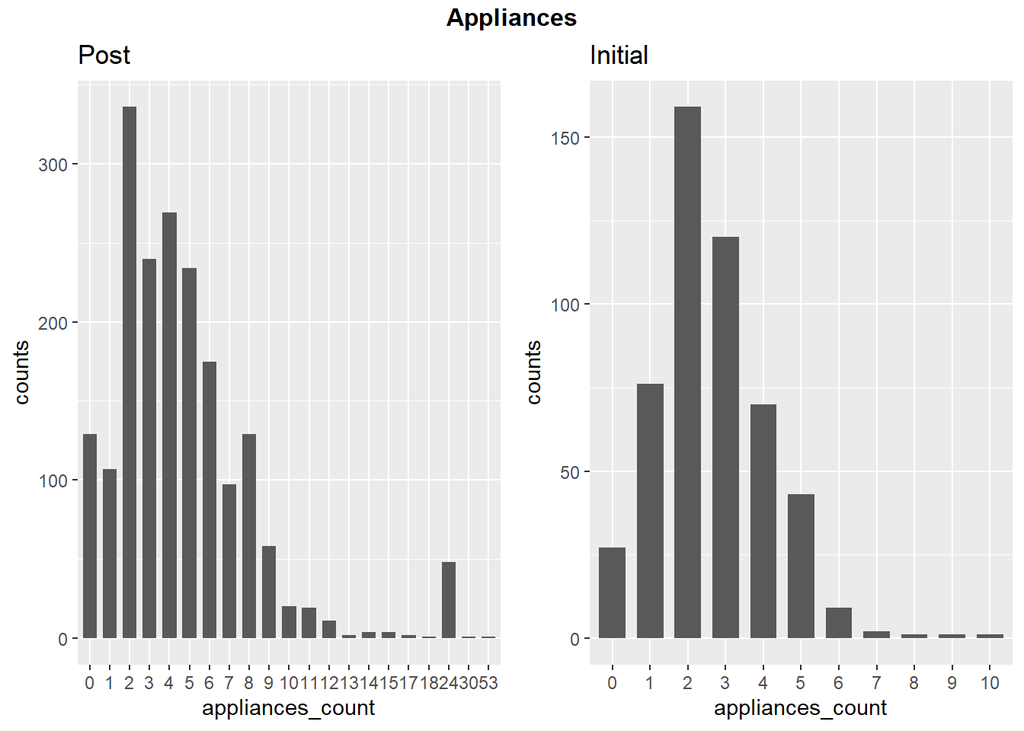

```r
# How many electronic devices or appliances do you currently use in the household
compare_pre_post(var_name="appliances_count", var_type="non_cont",
                 subplot_type="bar_discrete", title="Appliances",
                 char_remove=NULL)
```

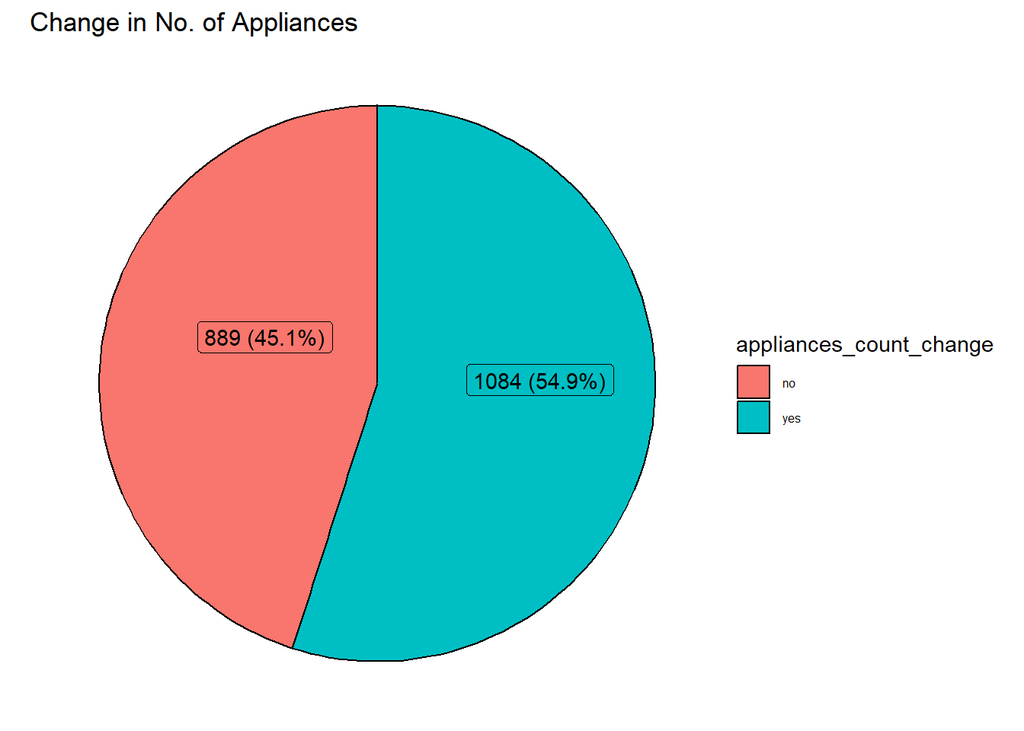

```r
# Has the number of electronic devices or appliances increased since connection to minigrid?
plot_func(df=post_clean, var_name="appliances_count_change",
          var_type="non_cont", plot_title="Change in No. of Appliances",
          plot_type="pie", char_remove=NULL)
```

### Phone Charge - Travel Distance

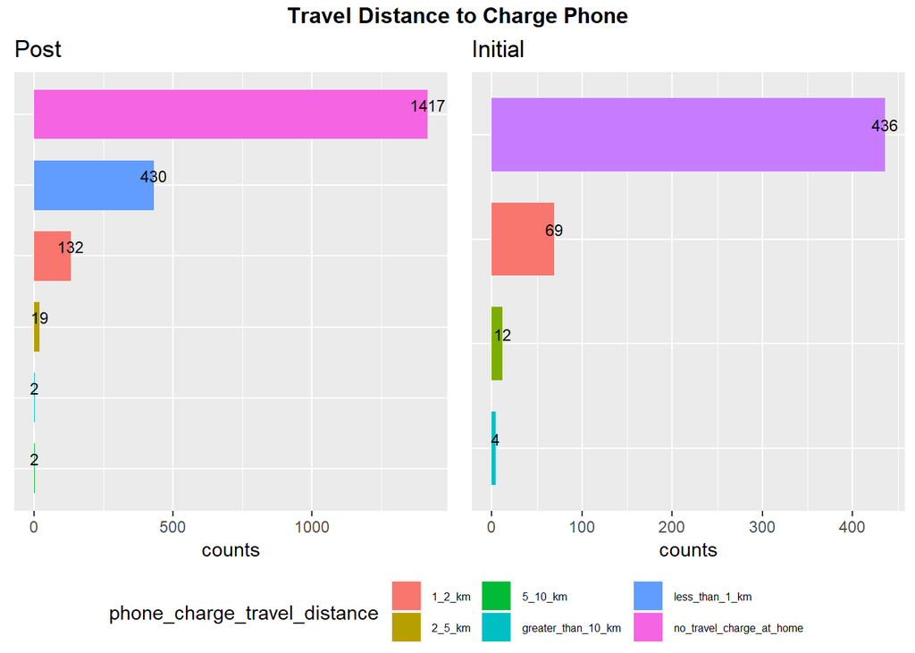

```r
# How far must you travel to charge your mobile phone?
compare_pre_post(var_name="phone_charge_travel_distance", var_type="non_cont",
                 subplot_type="bar", title="Travel Distance to Charge Phone",
                 char_remove=NULL)
```

### Water Collection - Travel Distance

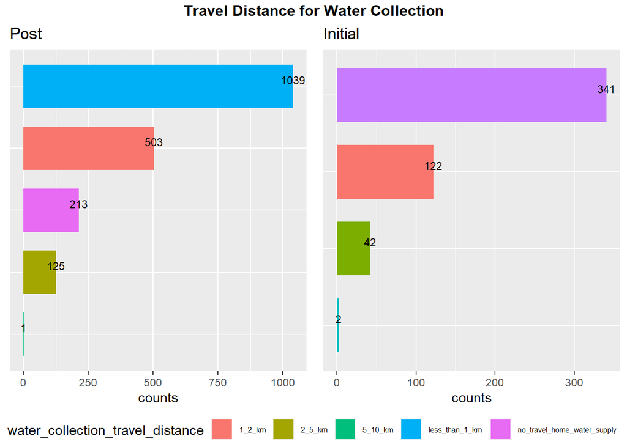

```r
# How far must you travel to obtain your water supply?
compare_pre_post(var_name="water_collection_travel_distance", var_type="non_cont",
                 subplot_type="bar", title="Travel Distance for Water Collection",
                 char_remove=NULL)
```

### Water Collection Time

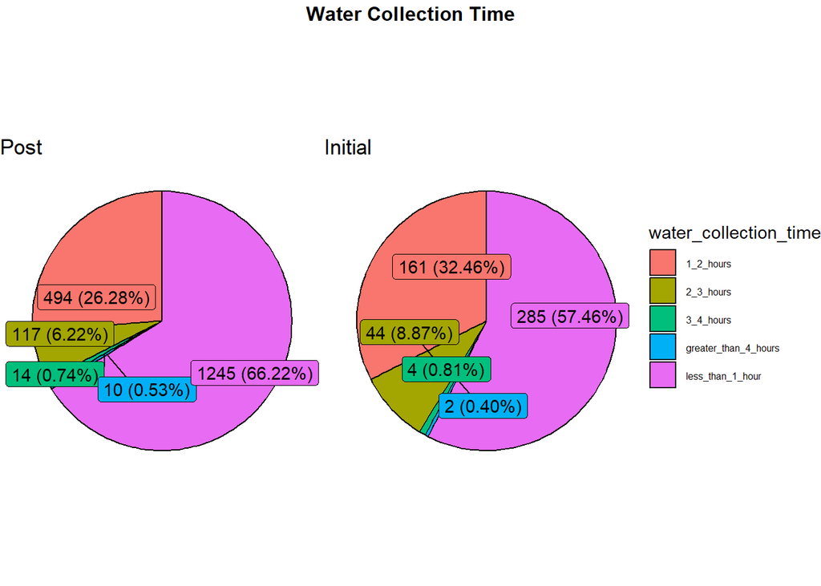

```r
compare_pre_post(var_name="water_collection_time", var_type="non_cont",
                 subplot_type="pie", title="Water Collection Time",
                 char_remove=NULL)
```

### C&I - Profile

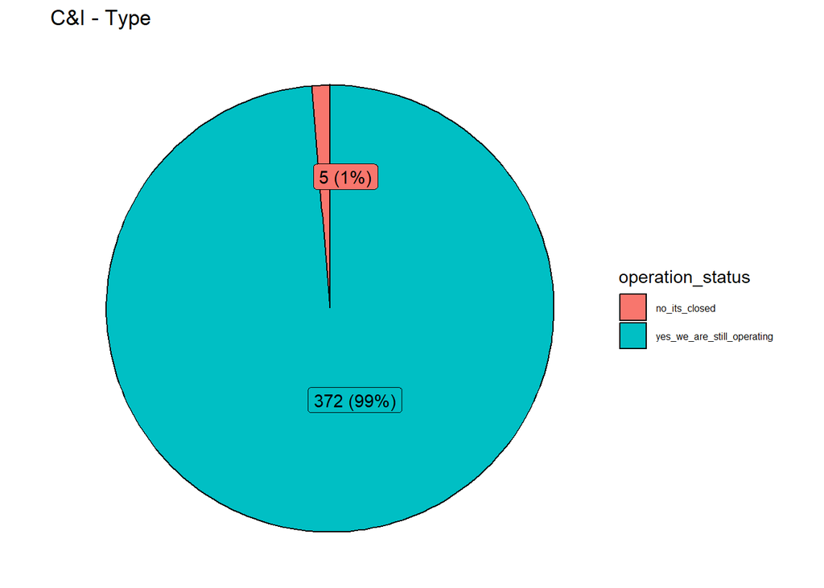

```r
# Is this business, clinic, school still in operation?
plot_func(df=ci_clean, var_name="operation_status",
          var_type="non_cont", plot_title="C&I - Type",
          plot_type="pie", char_remove=NULL)
```

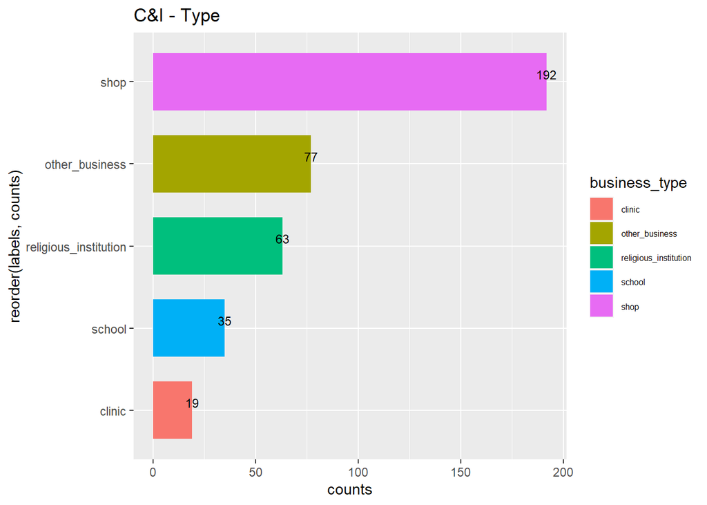

```r
# Please select your business type
plot_func(df=ci_clean, var_name="business_type",
          var_type="non_cont", plot_title="C&I - Type",
          plot_type="bar", char_remove=NULL)
```

### C&I - Operation Hours

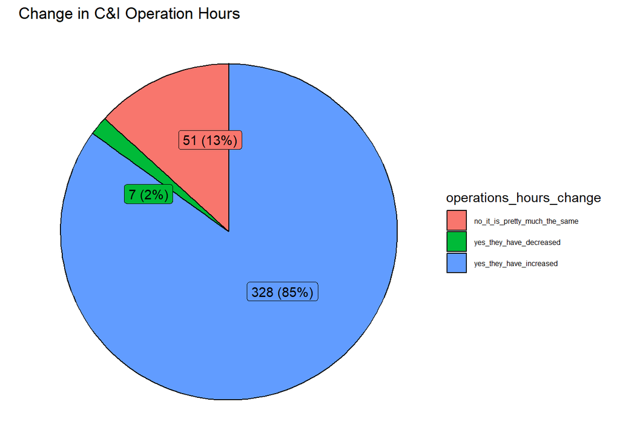

```r
# Since connection to Renewvia minigrid, have your hours of operation changed at all?
plot_func(df=ci_clean, var_name="operations_hours_change",
          var_type="non_cont", plot_title="Change in C&I Operation Hours",
          plot_type="pie", char_remove=NULL)
```

### C&I - Workforce

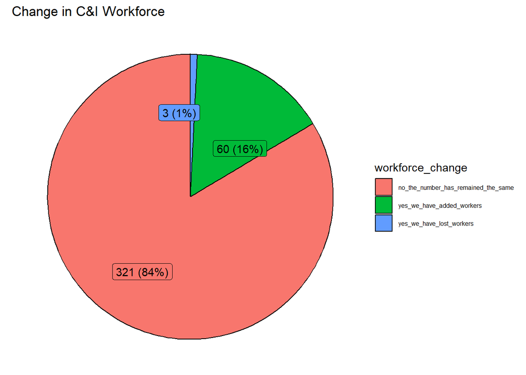

```r
# Since connection to Renewvia mingrid, have you had any change in number of workers/employees at your place of work?
plot_func(df=ci_clean, var_name="workforce_change",
          var_type="non_cont", plot_title="Change in C&I Workforce",
          plot_type="pie", char_remove=NULL)
```

### C&I - New Products/Services

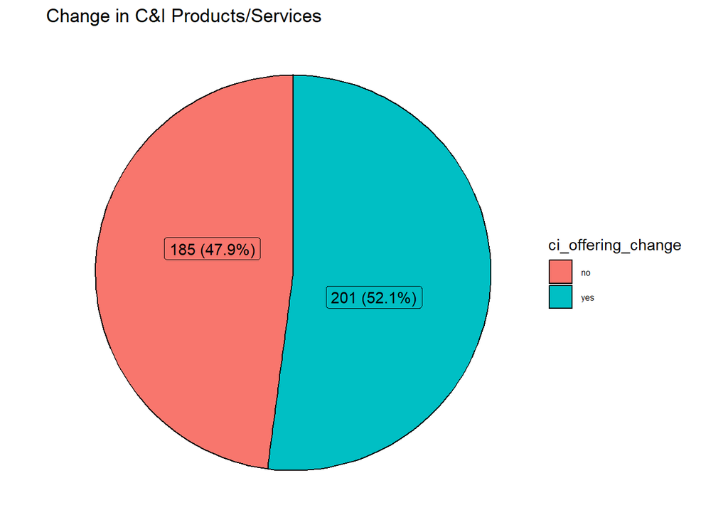

```r
# Have you added any new products or services since connection to Renewvia minigrid?
plot_func(df=ci_clean, var_name="ci_offering_change",
          var_type="non_cont", plot_title="Change in C&I Products/Services",
          plot_type="pie", char_remove=NULL)
```

## B) Inferential

### No. of Appliances*

**Data Source**: Paired Household Surveys (Pre & Post)

**Value (Encoding if applied)**: Any numeric value

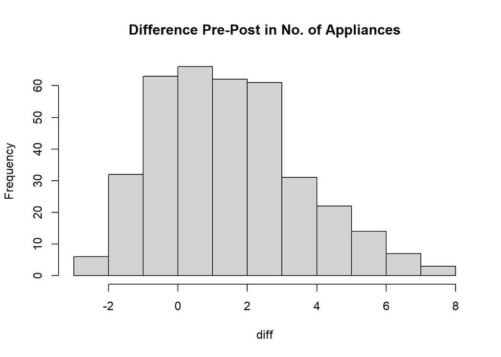

```
##
##  Paired t-test
##
## data:  var_pre and var_post
## t = -17.8, df = 366, p-value < 0.00000000000000022
## alternative hypothesis: true mean difference is not equal to 0
## 95 percent confidence interval:
##  -2.169518 -1.737839
## sample estimates:
## mean difference
##       -1.953678
```

```r
paired_testing(paired_enc, var_name = "appliances_count",
               plot_diff = TRUE, plot_title = "Difference Pre-Post in No. of Appliances",
               test_type="ttest", remove_outliers=TRUE)
```

```r
community_reg(df=paired_enc, calc_diff = TRUE,
              col_name="appliances_count", dep="V1",
              title="Difference in No. of Appliances by Community",
              var_type="ratio")
```

```
## [1] "pv_size_kwh"
##                Estimate Std. Error    t value  Pr(>|t|)
## Intercept   57.88303891 24.3578207  2.3763636 0.0335350
## pv_size_kwh -0.07451449  0.1705552 -0.4368936 0.6693577
##                            2.5 %      97.5 %
## (Intercept)            5.2611665 110.5049113
## community_data[, ind] -0.4429766   0.2939477
## [1] "customer_count"
##                    Estimate  Std. Error    t value   Pr(>|t|)
## Intercept      56.263929135 26.42205122  2.1294308 0.05290431
## customer_count -0.007122316  0.03502616 -0.2033428 0.84201544
##                             2.5 %      97.5 %
## (Intercept)           -0.81744216 113.3453004
## community_data[, ind] -0.08279174   0.0685471
## [1] "capex_usd"
##                Estimate    Std. Error    t value  Pr(>|t|)
## Intercept 51.9248323966 38.0125418340 1.36599211 0.1951079
## capex_usd  0.0000051195  0.0001122095 0.04562448 0.9643030
##                                2.5 %         97.5 %
## (Intercept)           -30.1962715340 134.0459363272
## community_data[, ind]  -0.0002372944   0.0002475334
## [1] "consumption"
##                  Estimate    Std. Error    t value   Pr(>|t|)
## Intercept   63.7372020811 26.8925691679  2.3700674 0.03393168
## consumption -0.0001814366  0.0002742256 -0.6616326 0.51976244
##                              2.5 %         97.5 %
## (Intercept)            5.639338559 121.8350656032
## community_data[, ind] -0.000773865   0.0004109918
```

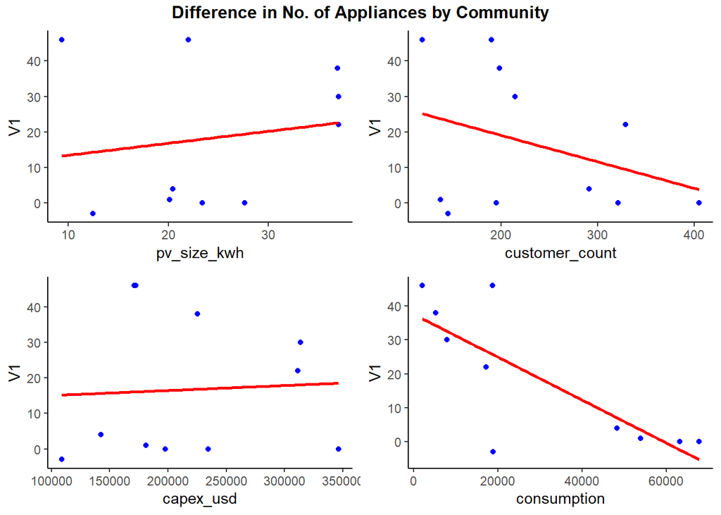

```r
consumption_reg(df = paired_enc, reg_type ="linear",
                dep= "appliances_count", calc_diff=TRUE,
                title="Energy Consumption vs. Difference in No. of Appliances")
```

```
##
## Call:
## lm(formula = df$col_reg ~ df$Energy.Consumption)
##
## Residuals:
##     Min      1Q  Median      3Q     Max
## -6.1540 -2.0866 -0.0991  0.9154 19.8927
##
## Coefficients:
##                        Estimate Std. Error t value            Pr(>|t|)
## (Intercept)           2.0841475  0.1456086  14.313 <0.0000000000000002 ***
## df$Energy.Consumption 0.0004995  0.0014751   0.339               0.735
## ---
## Signif. codes:  0 '***' 0.001 '**' 0.01 '*' 0.05 '.' 0.1 ' ' 1
##
## Residual standard error: 2.565 on 378 degrees of freedom
##   (89 observations deleted due to missingness)
## Multiple R-squared:  0.0003033,  Adjusted R-squared:  -0.002341
## F-statistic: 0.1147 on 1 and 378 DF,  p-value: 0.7351
##
##                              2.5 %      97.5 %
## (Intercept)            1.797843085 2.370451840
## df$Energy.Consumption -0.002400794 0.003399892
```

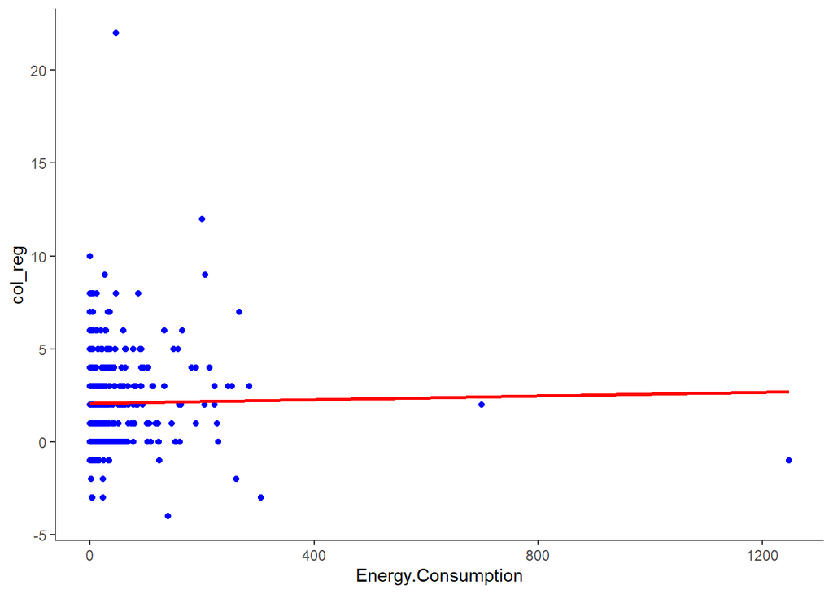

### Light Hours*

**Data Source**: Paired Household Surveys (Pre & Post)

**Value (Encoding if applied)**: Any numeric value between 0 and 24

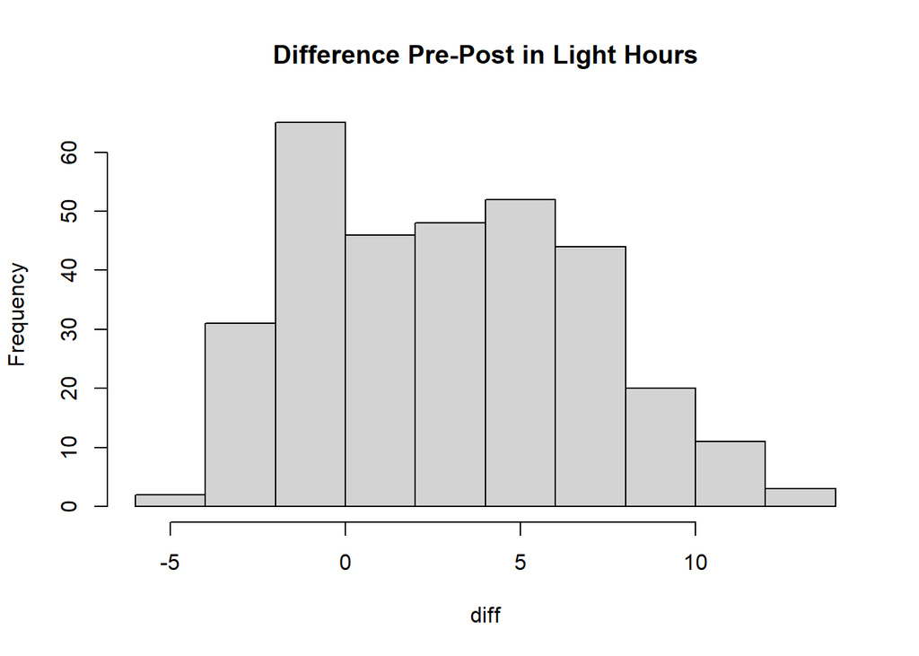

```
##
##  Paired t-test
##
## data:  var_pre and var_post
## t = -15.592, df = 321, p-value < 0.00000000000000022
## alternative hypothesis: true mean difference is not equal to 0
## 95 percent confidence interval:
##  -3.833198 -2.974256
## sample estimates:
## mean difference
##       -3.403727
```

```r
## How many hours of light per day do you currently have at home?
paired_testing(paired_enc, var_name = "light_hours_current",
               plot_diff = TRUE, plot_title = "Difference Pre-Post in Light Hours",
               test_type="ttest", remove_outliers=TRUE)
```

```r
community_reg(df=paired_enc, calc_diff = TRUE,
              col_name="light_hours_current", dep="V1",
              title="Difference in Light Hours by Community",
              var_type="ratio")
```

```
## [1] "pv_size_kwh"
##              Estimate Std. Error    t value  Pr(>|t|)
## Intercept   82.597863 47.0510612  1.7554942 0.1026938
## pv_size_kwh -0.176846  0.3294549 -0.5367836 0.6004836
##                             2.5 %      97.5 %
## (Intercept)           -19.0497746 184.2455010
## community_data[, ind]  -0.8885901   0.5348981
## [1] "customer_count"
##                   Estimate  Std. Error    t value  Pr(>|t|)
## Intercept      79.05682212 51.17481765  1.5448384 0.1463734
## customer_count -0.01763648  0.06783945 -0.2599738 0.7989560
##                             2.5 %      97.5 %
## (Intercept)           -31.4996499 189.6132942
## community_data[, ind]  -0.1641947   0.1289217
## [1] "capex_usd"
##                 Estimate  Std. Error    t value  Pr(>|t|)
## Intercept 79.42316281815 73.65747139  1.0782771 0.3005118
## capex_usd -0.00002770802  0.00021743 -0.1274342 0.9005468
##                               2.5 %         97.5 %
## (Intercept)           -79.704129694 238.5504553302
## community_data[, ind]  -0.000497437   0.0004420209
## [1] "consumption"
##                  Estimate    Std. Error    t value  Pr(>|t|)
## Intercept   90.7557248544 52.2409657160  1.7372521 0.1059597
## consumption -0.0003305753  0.0005327051 -0.6205597 0.5456154
##                               2.5 %         97.5 %
## (Intercept)           -22.104020062 203.6154697705
## community_data[, ind]  -0.001481415   0.0008202642
```

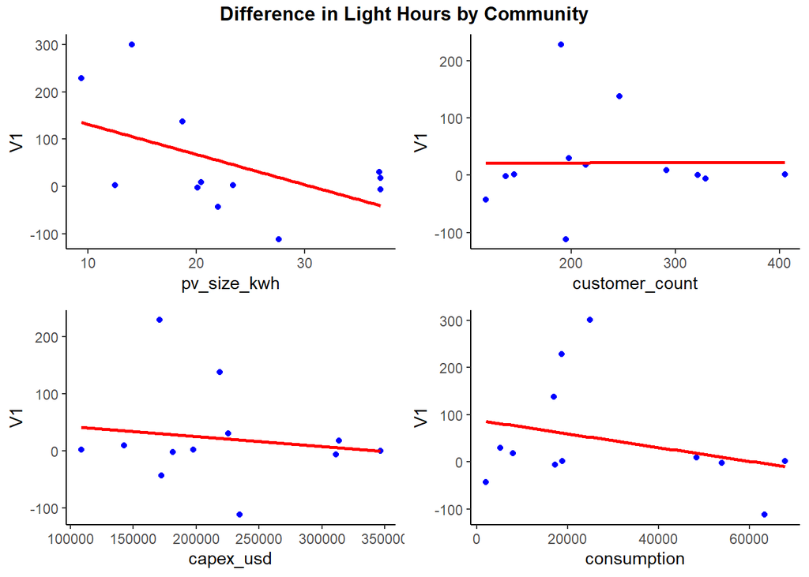

```r
consumption_reg(df = paired_enc, reg_type ="linear",
                dep= "light_hours_current", calc_diff=TRUE,
                title="Energy Consumption vs. Difference in Light Hours")
```

```
##
## Call:
## lm(formula = df$col_reg ~ df$Energy.Consumption)
##
## Residuals:
##     Min      1Q  Median      3Q     Max
## -22.996  -3.065   0.099   3.043  10.151
##
## Coefficients:
##                        Estimate Std. Error t value            Pr(>|t|)
## (Intercept)            3.102288   0.274599  11.298 <0.0000000000000002 ***
## df$Energy.Consumption -0.004037   0.002730  -1.479                0.14
## ---
## Signif. codes:  0 '***' 0.001 '**' 0.01 '*' 0.05 '.' 0.1 ' ' 1
##
## Residual standard error: 4.749 on 366 degrees of freedom
##   (101 observations deleted due to missingness)
## Multiple R-squared:  0.00594,    Adjusted R-squared:  0.003224
## F-statistic: 2.187 on 1 and 366 DF,  p-value: 0.1401
##
##                              2.5 %      97.5 %
## (Intercept)            2.562298696 3.642277835
## df$Energy.Consumption -0.009405153 0.001331266
```

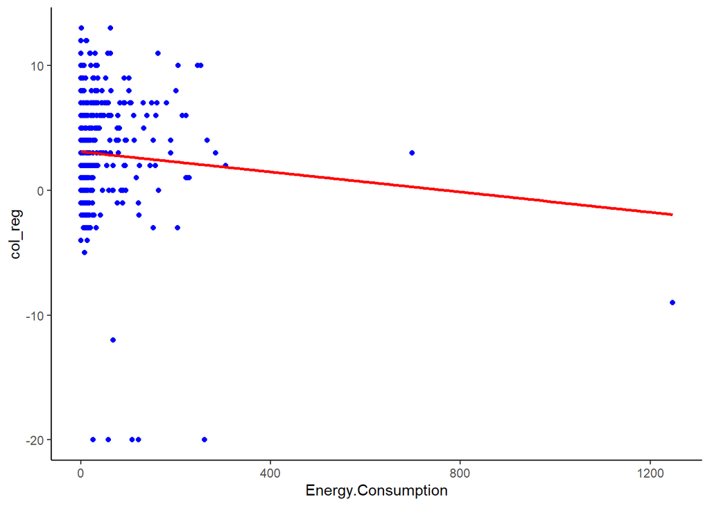